# Introduction to Applied Predictive Modeling

Michael Fichman

2025-02-14

# 1. Introduction

The world is awash in complex predictive tools and analytics. Some of these tools are very useful for planners and others concerned with social and spatial phenomena. The best way to develop utility with these kinds of tools is by starting with the basics - regression models. These models are interpretable, simple, and often deceptively powerful.

This is a beginner’s guide to predictive analytics. It introduces a few simple model workflows and basic concepts to users who have little or no background working with statistics and/or computer coding. It is NOT a comprehensive text on regression models. Such texts are many in number, but if you want to get into one - I quite like [Regression and other Stories, by Gelman et al](https://avehtari.github.io/ROS-Examples/examples.html#Introduction).

This document details regression models we will use this semester in Land Use and Environmental Modeling (CPLN 6750 and the University of Pennsylvania Weitzman School of Design), and provides basic workflows using sample data sets.

**The learning objectives are as follows:**

1. Understand what it means to “model” data using regression.
2. Understand how regression models can be used to estimate outcomes, and learn how model selection is related to the outcome of interest.
3. Observe and understand the training and testing workflow used to validate models in R with the `caret` package.
4. Learn basic terminology and statistics associated with OLS and binomial logit regression and the `lm` and `glm` functions for building models.
5. Understand the notion of model “accuracy” and “generalizability”
6. Learn how feature engineering and spatial data can be used to improve model quality.

**Instructions**

You can use this document in two ways. You can read along and look at the code, charts and outputs, or you can run the code in R-Studio and observe how it works.

## 1.1. Explanation versus Prediction

You very often see regression models used in scholarly papers to show the “effect of A on B” or the “association between A and B”… “all else equal.” In a public policy or planning context, causal and associative applications of regression are very useful for measuring policy effects or understanding social scientific relationships in a statistical framework. *This is NOT what we are going to do*. You will not hear any “A causes B” in this text. Furthermore, we are not trying to isolate the associations between A and B, “all else equal.” What this means is that we are going to violate some assumptions (e.g. the “rules”) that you will learn in most stats courses, which use these models for *explanation*.

We are going to use regression models for a different purpose - to make precictions, or forecasts. This means we will estimate outcomes (dependent variables) using a bunch of predictors (independent variables). To give you an example of the difference in approach, if I want to estimate the heights of a number of people, I could do so very accurately if I fed a regression model information about their wingspans. However, that can’t tell me anything about WHY a person is so tall.

The key to making *above average* predictive models is finding good independent variables and harnessing the power of their correlation with the dependent variable to make predictions. They key to making *great* predictive models is “engineering” good “features” to make models that are both accurate and flexible.

## 1.2. Model Types

**We are going to demonstrate the use of two types of models**, each is designed to suit a different type of outcome variable. First, we will use **Ordinary Least Squares (OLS) regression** to estimate normally distributed, continuous outcomes. Second we will use **binary logistic regression** to estimate 0/1 outcomes (e.g. estimating the probability of an outcome being a 1). Lastly, we will do some **feature engineering using spatial data for OLS**.

*Your choice of model depends on the use case - is the outcome you are interested in binomial or continuous?*

There are other models for different outcome types not covered here, including Poisson regression for count data. Here is a basic guide to some linear models by dependent variable (DV) type.

| Model Type | DV Type | DV Example |
| --- | --- | --- |
| OLS | Continuous | Home Prices |
| Logit | Binary | Inspection Pass/Fail of Restaurants |
| Poisson | Counts | Inspection Violations by Neighborhood |

## 1.3. How Do Predictive Models “Work?”

These models are built around a simple framework - making a *“best fit”* line through your data. You’ve certainly seen an x-y scatterplot with a fitted line plotted through the middle (see the figure below). This is actually a simple regression model.

Our models fit functions that minimizes the distance between the observations (the error) and the best fit line. We draw our predictions from this “best fit” line - what is the value of Y for a given X?

Each of the models in this text apply a different fitted function to your data, but in the end, the predictive functionality is similar - they all output the “average” estimate given all the independent predictor variables in the model.

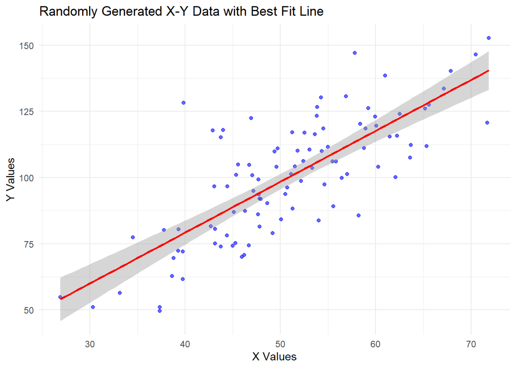

## 1.4 How Do You Assess Model Performance?

How do you know if your predictive model is doing a good job? We do this by **“validating” the model** - using our model to predict for observations where we *know* the outcomes, and can compare its performance to real-life observations. If we are doing this well, we can feel confident about using our model to make forecasts.

In practice, we do this by using *training* and *testing* data. We set aside a subset of our data we call the **test set**, say, 25% of our data. We **train* a model with the remaining 75%. We then make predictions for our 25% test set, and see if our our model can accurately estimate the outcome.

**We will have a few ways to judge performance:**

- Is the model accurate on unseen data? Are the predictions close to the known values in our test set?
- Does the model work well across contexts? Do we have big errors with some particular category of observation and small ones with another?

The metrics used to judge model quality depend on what type of model you are using, as we will see.

## 1.5. R Packages

We will use a few basic packages in this text.

If you do not have any of the packages listed below installed on your computer, install them like so:

```r
install.packages('tidyverse')
```

If you have already installed a package on your computer, you can load it into your environment using the `library` command.

`tidyverse` is the main family of data wrangling and visualization packages in R, including `ggplot2` and `dplyr`

`sf` is the primary vector GIS package in the tidyverse, short for “Simple Features”

`caret` is a package with tools for predictive modeling - training and testing models.

`readr` is a package for reading in some data types, like Excel files.

`plotROC` is a package used to create an ROC curve - a diagnostic test for logit models.

```r
library(tidyverse)
library(sf)
library(caret)
library(readr)
library(plotROC)
```

# 2. Ordinary Least Squares Linear Regression

OLS regression, or multiple linear regression, is a simple model that can estimate the value of a *continuous* outcome - like prices or quantities. It is simple, interpretable, and widespread. You have almost certainly seen this kind of model in a two-variable scenario, where a line is fitted to a cloud of points (like in the last section). Imagine a multi-dimensional cloud of points with a fitted line - that’s essentially what multiple linear regression does.

## 2.1. Data set

We are going to use a [data set from the World Bank](https://www.kaggle.com/datasets/patelris/crop-yield-prediction-dataset?select=yield.csv) to see if we can predict national crop yields. This data set consists of agricultural yields for many types of crops in over 100 countries. There is accompanying info about yearly rainfall and temperature. I have cleaned these data a bit to consist only of a few years.

Let’s say we are interested in food system planning, and **we want to be able to predict the yield (weight per hectre) for several crop types in multiple countries** - maize, wheat, etc.,

We can load our data from a URL where it is hosted on github:

```r
yield_df <- read_csv("https://raw.githubusercontent.com/mafichman/applied_predictive_modeling/refs/heads/main/data/yield_df_clean.csv")
```

## 2.2. Exploratory Analysis

The first step is always to do a few quick pieces of exploratory data analysis - looking at the data types in your set, the distributions of the data, and the correlations between different variables.

### 2.2.1. Data types

The `glimpse` command from `dplyr` in the `tidyverse` is the best way to quickly look at your data. Here we see that we have rows that have a column id, a country, a crop type, a year, yield per hectare (our continuous dependent variable - `yield_hg_per_ha`)

```r
glimpse(yield_df)
```

```
## Rows: 1,763
## Columns: 10
## $ ...1                          <dbl> 1, 2, 3, 4, 5, 6, 7, 8, 9, 10, 11, 12, 1…
## $ ...2                          <dbl> 87, 91, 95, 88, 92, 96, 89, 93, 97, 90, …
## $ Area                          <chr> "Albania", "Albania", "Albania", "Albani…
## $ Item                          <chr> "Maize", "Maize", "Maize", "Potatoes", "…
## $ Year                          <dbl> 2011, 2012, 2013, 2011, 2012, 2013, 2011…
## $ yield_hg_per_ha               <dbl> 59869, 67290, 69533, 242211, 250538, 260…
## $ average_rain_fall_mm_per_year <dbl> 1485, 1485, 1485, 1485, 1485, 1485, 1485…
## $ pesticides_tonnes             <dbl> 1302.63, 766.25, 982.32, 1302.63, 766.25…
## $ avg_temp                      <dbl> 16.45, 16.70, 17.41, 16.45, 16.70, 17.41…
## $ yield_last_year               <dbl> 66790, 59869, 67290, 231111, 242211, 250…
```

### 2.2.2. Distributions

We can look at how our continuous variables are distributed. Some of them are similar - very right-tailed (including our dependent variable). Others are a bit all over the place.

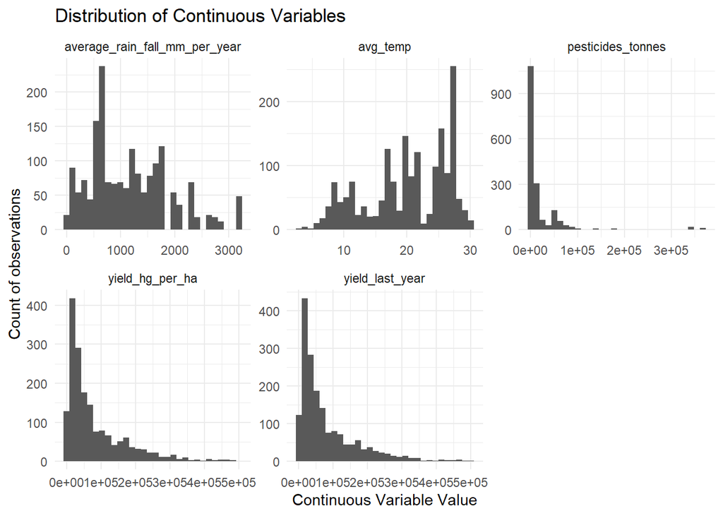

```r
yield_df %>%
  select(yield_hg_per_ha, average_rain_fall_mm_per_year, yield_last_year, pesticides_tonnes, avg_temp) %>%
  gather(key = "variable", value = "value") %>%
  ggplot()+
  geom_histogram(aes(value))+
  facet_wrap(~variable, scales = "free")+
  theme_minimal()+
  labs(title = "Distribution of Continuous Variables",
       x = "Continuous Variable Value",
       y = "Count of observations")
```

### 2.2.3. Correlations - Continuous Variables

Good predictive modeling is all about harnessing the power of correlation between independent predictors and your dependent variable. Take a look at how your continuous variables might be correlated with your outcome variable `yield_hg_per_ha`

A few notable observations - it seems that there is little relationship between yield and rainfall, there are some major outliers in pesticide application amounts, and that a previous year’s yield by crop and country has a very, very strong relationship to current year yield.

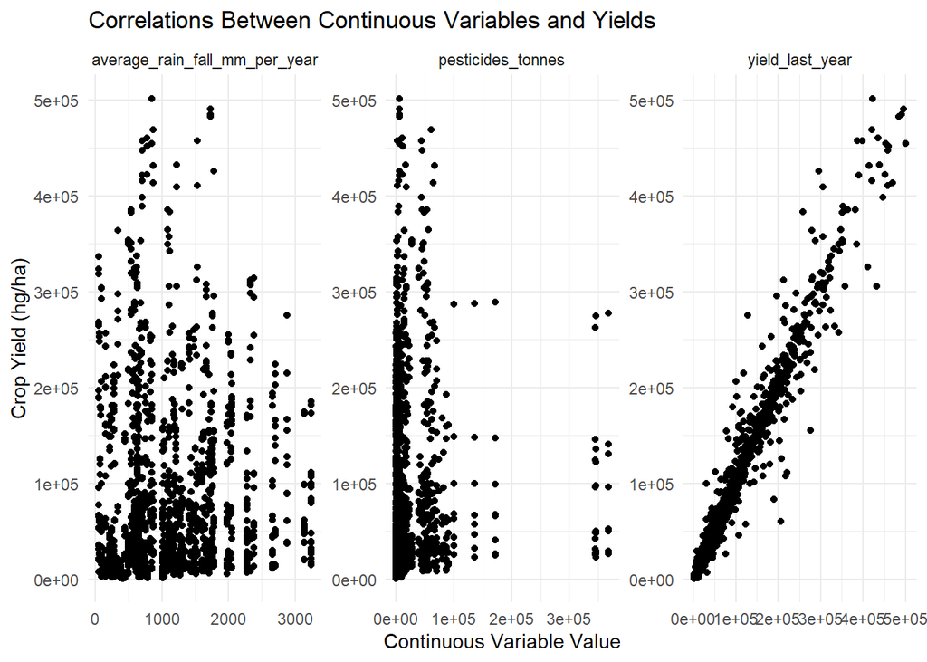

```r
yield_df %>%
  select(yield_hg_per_ha, average_rain_fall_mm_per_year, yield_last_year, pesticides_tonnes) %>%
  gather(-yield_hg_per_ha, key = "variable", value = "value") %>%
  ggplot()+
  geom_point(aes(x = value, y = yield_hg_per_ha))+
  facet_wrap(~variable, scales = "free")+
  theme_minimal() +
  labs(title = "Correlations Between Continuous Variables and Yields",
       x = "Continuous Variable Value",
       y = "Crop Yield (hg/ha)")
```

The Pearson’s product-moment correlation, aka “Pearson’s R” is a simple test of correlation between two continuous variables. It runs between -1 (strong negative correlation), and 1 (strong positive). A Pearson’s R of 0 would mean no relationship.

Let’s look at the Pearson’s R between our yield and pesticide application - it’s pretty small - 0.05 is the Pearson’s R estimate we see in the output from the `cor.test` function.

`cor.test` takes two arguments - two columns from our data set.

```r
cor.test(yield_df$yield_hg_per_ha, yield_df$pesticides_tonnes)
```

```
##
##  Pearson's product-moment correlation
##
## data:  yield_df$yield_hg_per_ha and yield_df$pesticides_tonnes
## t = 2.3001, df = 1761, p-value = 0.02156
## alternative hypothesis: true correlation is not equal to 0
## 95 percent confidence interval:
##  0.008064729 0.101155366
## sample estimates:
##        cor
## 0.05472897
```

### 2.2.4. Categorical variables

Let’s examine how our dependent variable might vary from category to category.

This is a bit messy, but we can see that from country to country, and crop to crop, there is a lot of variation in yield. The fact that there are differences across categories means that this will probably be a good predictor in our model. If they were all the same, it wouldn’t give us much predictive power.

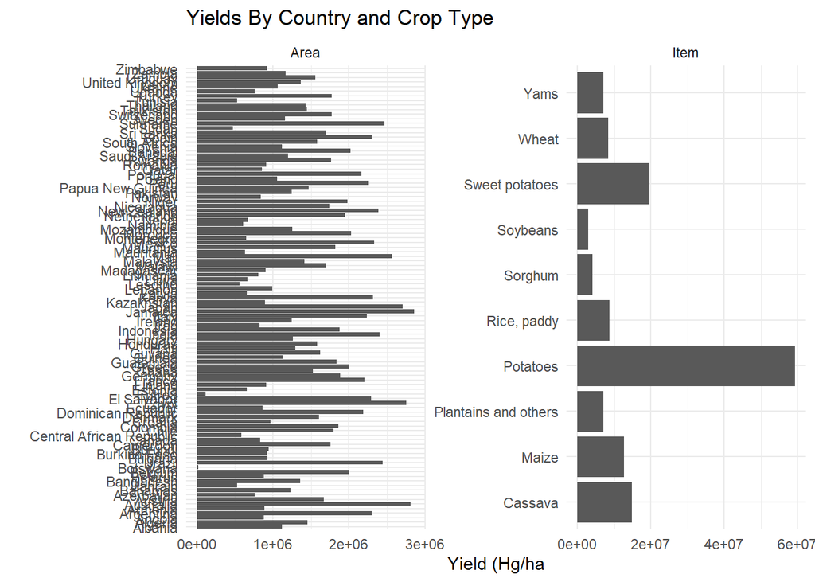

```r
yield_df %>%
  select(yield_hg_per_ha, Area, Item) %>%
  gather(-yield_hg_per_ha, key = "variable", value = "value") %>%
  ggplot()+
  geom_bar(aes(x = value, y = yield_hg_per_ha), stat = "identity")+
  facet_wrap(~variable, scales = "free")+
  coord_flip()+
  theme_minimal() +
  labs(title = "Yields By Country and Crop Type",
       x = "",
       y = "Yield (Hg/ha")
```

## 2.3. A Simple Model

Here’s a simple example so we can take a look at our modeling outputs. Let’s start by predicting yield using only rain fall, temperature and the amount of pesticides. Look at the following code chunk to see how we do this with the `lm` function.

The `lm` function takes a data set (`yield_df`), and an equation with a dependent variable (`yield_hg_per_ha`) followed by a `~` (called a “tilda”). You list the independent variables on the other side of the tilda.

The lm function will output a model object, which we call `reg1`.

```r
reg1 <- lm(data = yield_df,
           yield_hg_per_ha ~
             average_rain_fall_mm_per_year + avg_temp + pesticides_tonnes)
```

You can use the `summary` command to look at the model outputs.

The model summary shows us a lot of information. Let’s just focus on a three items of information - Beta Coefficients, p-values, and R-Squared.

**The beta coefficients aka `Estimate`** - these show the strength (big or small) and the direction (positive or negative) of the relationship between an independent variable and our dependent variable (yield) given the other variables in the model. Here is an example of how they are interpreted using technical language. “On average, a one unit increase in `average_rain_fall_mm_per_year` is associated with a 5.335 unit increase in `yield_hg_per_ha`, all else equal.”

**The p-value `Pr(>|t|)`** represents the probability that this estimate is significantly different from zero (e.g. how much confidence do we have in the coefficient). A low p-value means a relatively high confidence in the estimate. Here it is `0.0773` - this is low, but not low enough to show significance of the relationship in the eyes of a medical journal reviewer. For our purposes, a 7% chance the estimate is invalid (aka a 93% chance it’s valid), means it might be useful predictor.

The **R-Squared** value tells us the amount of variance in the dependent variable that is explained by this combination of independent variables. This isn’t the same as an “accurate” model, but higher values generally relate to more powerful predictive models. Here, the value is 0.02 (on a scale of 0-1) - which is horrible.

```r
summary(reg1)
```

```
##
## Call:
## lm(formula = yield_hg_per_ha ~ average_rain_fall_mm_per_year +
##     avg_temp + pesticides_tonnes, data = yield_df)
##
## Residuals:
##     Min      1Q  Median      3Q     Max
## -101709  -59072  -35036   31225  405247
##
## Coefficients:
##                                 Estimate Std. Error t value Pr(>|t|)
## (Intercept)                    1.147e+05  6.848e+03  16.743  < 2e-16 ***
## average_rain_fall_mm_per_year  5.335e+00  3.019e+00   1.767   0.0773 .
## avg_temp                      -2.004e+03  3.394e+02  -5.906  4.2e-09 ***
## pesticides_tonnes              7.285e-02  4.315e-02   1.688   0.0915 .
## ---
## Signif. codes:  0 '***' 0.001 '**' 0.01 '*' 0.05 '.' 0.1 ' ' 1
##
## Residual standard error: 87350 on 1759 degrees of freedom
## Multiple R-squared:  0.02247,    Adjusted R-squared:  0.0208
## F-statistic: 13.48 on 3 and 1759 DF,  p-value: 1.075e-08
```

**Do we care about the beta coefficients, the p-values and the R-squared?**

Only a little bit. We want to know whether these variables in this model predict yields well - we don’t care about explaining their effects in isolation. We can use the magnitude, directionality, and significance of our coefficients as diagnostics as we are building our model - adding features and engineering new ones. The real metrics we care about are prediction errors - which we discuss a bit later.

## 2.4. Fixed Effects

It would stand to reason that the model “knowing” what country and crop type you’re predicting would help make a more accurate prediction. Our exploratory analysis told us that yields vary a lot across crop and country.

Let’s add a *“categorical” variable* to our model - `Item` - aka crop type. When you add a categorical variable, like crop type, it’s known as a *“fixed effect” or a “dummy variable”*.

Let’s create a new regression, called `reg2`, and examine the model summary.

Each category level (e.g. Maize) has it’s own line item in the regression summary. One level of the fixed effect is not represented in the summary - so there’s one crop you don’t see in the summary (Cassava). The statistics for each level relate to that “base case” hold out.

In this regression - each coefficient can be interpreted like so - *“all else equal, the average Maize crop yield is 85,630 hg/hectare lower than Cassava.”*. The negative sign means a lower yield.

Adding these fixed effects made our R-Squared go wayyyy up - if we know the rainfall, crop and pesticide application, we can explain almost 60% of the variance in crop yields. Pretty good - but again - R-squared is not the metric we care about the most.

```r
reg2 <- lm(data = yield_df,
           yield_hg_per_ha ~
             average_rain_fall_mm_per_year + avg_temp + pesticides_tonnes + Item)

summary(reg2)
```

```
##
## Call:
## lm(formula = yield_hg_per_ha ~ average_rain_fall_mm_per_year +
##     avg_temp + pesticides_tonnes + Item, data = yield_df)
##
## Residuals:
##     Min      1Q  Median      3Q     Max
## -178265  -23802   -4195   17759  277113
##
## Coefficients:
##                                 Estimate Std. Error t value Pr(>|t|)
## (Intercept)                    1.782e+05  7.412e+03  24.043  < 2e-16 ***
## average_rain_fall_mm_per_year  4.486e-02  1.955e+00   0.023    0.982
## avg_temp                      -2.498e+03  2.265e+02 -11.033  < 2e-16 ***
## pesticides_tonnes              1.142e-01  2.751e-02   4.150 3.48e-05 ***
## ItemMaize                     -8.563e+04  6.141e+03 -13.943  < 2e-16 ***
## ItemPlantains and others      -5.822e+03  8.622e+03  -0.675    0.500
## ItemPotatoes                   7.461e+04  6.171e+03  12.092  < 2e-16 ***
## ItemRice, paddy               -8.406e+04  6.415e+03 -13.104  < 2e-16 ***
## ItemSorghum                   -1.079e+05  6.484e+03 -16.637  < 2e-16 ***
## ItemSoybeans                  -1.173e+05  6.693e+03 -17.532  < 2e-16 ***
## ItemSweet potatoes             2.735e+03  6.732e+03   0.406    0.685
## ItemWheat                     -1.041e+05  6.407e+03 -16.256  < 2e-16 ***
## ItemYams                      -2.221e+03  8.696e+03  -0.255    0.798
## ---
## Signif. codes:  0 '***' 0.001 '**' 0.01 '*' 0.05 '.' 0.1 ' ' 1
##
## Residual standard error: 55520 on 1750 degrees of freedom
## Multiple R-squared:  0.6071, Adjusted R-squared:  0.6044
## F-statistic: 225.4 on 12 and 1750 DF,  p-value: < 2.2e-16
```

We saw there is a *very* strong relationship between yield and `yield_last_year`. Let’s see what happens if we put this in a new model called `reg3`.

Check out the model summary. We now have a *very* high R-squared.

Now, rainfall, temperature and pesticides do not have low p-values. They offer very little predictive power compared to last year’s yields. This is exciting, *our model seems very powerful, but it’s worth considering the downside* - if we believe that rainfall has an effect on plant productivity, and we want to use this model to forecast yields in a sudden drought, it might not do a good job, because its power is based mostly on year-to-year trends.

```r
reg3 <- lm(data = yield_df, yield_hg_per_ha ~ average_rain_fall_mm_per_year +
                       avg_temp + pesticides_tonnes + Item + yield_last_year)

summary(reg3)
```

```
##
## Call:
## lm(formula = yield_hg_per_ha ~ average_rain_fall_mm_per_year +
##     avg_temp + pesticides_tonnes + Item + yield_last_year, data = yield_df)
##
## Residuals:
##     Min      1Q  Median      3Q     Max
## -139507   -3952    -418    2651  146327
##
## Coefficients:
##                                 Estimate Std. Error t value Pr(>|t|)
## (Intercept)                    9.175e+03  2.628e+03   3.491 0.000492 ***
## average_rain_fall_mm_per_year -3.099e-01  6.015e-01  -0.515 0.606502
## avg_temp                      -8.580e+01  7.212e+01  -1.190 0.234335
## pesticides_tonnes              5.624e-03  8.506e-03   0.661 0.508539
## ItemMaize                     -5.231e+03  1.989e+03  -2.630 0.008615 **
## ItemPlantains and others      -1.512e+03  2.653e+03  -0.570 0.568632
## ItemPotatoes                   4.313e+03  1.975e+03   2.184 0.029074 *
## ItemRice, paddy               -4.839e+03  2.066e+03  -2.342 0.019299 *
## ItemSorghum                   -6.385e+03  2.143e+03  -2.979 0.002931 **
## ItemSoybeans                  -6.735e+03  2.229e+03  -3.021 0.002556 **
## ItemSweet potatoes             1.749e+03  2.071e+03   0.845 0.398371
## ItemWheat                     -5.416e+03  2.113e+03  -2.563 0.010466 *
## ItemYams                      -6.160e+02  2.675e+03  -0.230 0.817914
## yield_last_year                9.620e-01  7.434e-03 129.391  < 2e-16 ***
## ---
## Signif. codes:  0 '***' 0.001 '**' 0.01 '*' 0.05 '.' 0.1 ' ' 1
##
## Residual standard error: 17080 on 1749 degrees of freedom
## Multiple R-squared:  0.9628, Adjusted R-squared:  0.9626
## F-statistic:  3486 on 13 and 1749 DF,  p-value: < 2.2e-16
```

## 2.5. Training and Testing

OK, now let’s set up a prediction workflow. We cut up our data into a “training” and “testing” set - we “train” the model on one set, and then use it to predict on the “test” set where we know the yields already. The difference between the observed and predicted yields is our error.

### 2.5.1. Splitting our Data

Here is the splitting procedure using the `caret` package:

-We use the `set.seed` command to generate a random number sequence. ’ -We then use the `createDataPartition` command from the `caret` package to split our data.

-The `p` argument takes a number - here we say `.70` to indicate that we want 70% of our data in the training set. There’s no set rule for the split size.

-The `paste` command is where we specify categorical variables - we want to make sure that single observations of categories end up in our test set. Why? If we train a model and it hasn’t “seen” one of our countries, and then we “show” it that country in the test set, it won’t be able to make a prediction for it.

-This process creates two data frames, which we name `yield_training` and `yield_test`

```r
set.seed(1234)

inTrain <- createDataPartition(
              y = paste(yield_df$Area),
              p = .70, list = FALSE)


yield_training <- yield_df[inTrain,]
yield_test <- yield_df[-inTrain,]
```

### 2.5.2. Creating a Regression

Let’s put our independent variables from `reg3` - the one with the year lag - into an `lm` object using `yield_training`, our training set. We’ll name this `reg.training_1`.

```r
reg.training_1 <-
  lm(data = yield_training,
     yield_hg_per_ha ~ average_rain_fall_mm_per_year +
                       avg_temp + pesticides_tonnes + Item + yield_last_year)
```

### 2.5.3. Predicting for our Test Set and Assessing Error

We can now use the `predict` function to “show” our test set `yield_test` to the model `reg.training_1`, and make a prediction for each row.

Our model only knows how to make predictions for a data frame that contains the exact same information it has “seen” when we trained it with`yield_training` - so your test set has to have exactly the same columns - same names, same data types - for this to work.

We want to know how much our predictions missed the mark - in absolute and percentage terms.

Here we create a new data frame called `yield_test_with_results`, we take `yield_test` and mutate some new columns - our `Prediction`, an `Error` that equals prediction minus actual, and measures of **Absolute Error** (`AbsError`) and **Absolute Percent Error** (`Abs_Pct_Error`) for each observation in the test set.

```r
yield_test_with_results <-
  yield_test %>%
  mutate(Prediction = predict(reg.training_1, yield_test),
         Error = Prediction - yield_hg_per_ha,
         AbsError = abs(Prediction - yield_hg_per_ha),
         Abs_Pct_Error = (abs(Prediction - yield_hg_per_ha)) / yield_hg_per_ha)
```

## 2.5.4. Accuracy and Generalizeability

**This is a critical step - we create some metrics that we use to assess model quality.**

To assess accuracy, we can summarize our errors - what is our **Mean Absolute Percentage Error (MAPE)**? What is our **Mean Absolute Error (MAE)**? This is very useful because it puts our errors into *understandable terms* - how much did we miss by? Easier to explain than R-squared!

Not bad! On average, our Mean Absolute Percentage Error tells us that we can predict yearly crop yields (on average) within ~14% of actual.

```r
yield_test_with_results %>%
  summarize(MAPE = mean(Abs_Pct_Error),
         MAE = mean(AbsError)) %>%
  kable() %>%
  kable_styling()
```

| MAPE | MAE |
| --- | --- |
| 0.14192 | 8075.591 |

The last thing we want to do is see if our model is *performing better or worse depending on the context* - testing for *generalizability*. It would be good to know if we are making accurate predictions about, say, soybeans, but missing badly on maize.

We can group our results by `Item` (`group_by`) and `summarize` our errors by crop type. As you can see, there is some variability.

```r
yield_test_with_results %>%
  group_by(Item) %>%
  summarize(MAPE = mean(Abs_Pct_Error),
         MAE = mean(AbsError)) %>%
  kable() %>%
  kable_styling()
```

| Item | MAPE | MAE |
| --- | --- | --- |
| Cassava | 0.2541651 | 16207.297 |
| Maize | 0.0974899 | 4489.536 |
| Plantains and others | 0.1522308 | 11914.502 |
| Potatoes | 0.1026540 | 20354.959 |
| Rice, paddy | 0.0986450 | 3537.859 |
| Sorghum | 0.1777100 | 2476.246 |
| Soybeans | 0.2067693 | 2369.595 |
| Sweet potatoes | 0.1517892 | 14880.642 |
| Wheat | 0.1186325 | 3373.426 |
| Yams | 0.1414759 | 12517.819 |

Are we doing a good job predicting for high yield observations *and* for low yield observations?

We can see if there is something systematic about our errors by *plotting the observed values against the predicted value*s. In the plot below, the blue line `y=x` represents a perfect prediction, where the observed and predicted value are the same, and the red line represents a line fitted to our predictions.

We do a very good job predicting these yields, but we can see that our errors are larger at higher yields - we seldom predict those observations accurately.

A note about generalizability, and flexibility - since we used the lag values (e.g. last year’s yield) of each crop/country combination - we saw that rainfall and pesticides were not significant in our model, which is strongly driven by the correlation between yield and last year’s yield. This means that our model is probably not flexible enough to predict next year’s yield as affected by a big change in rainfall. If your “use case” involves making weather-dependent predictions, maybe this isn’t a good model for you!

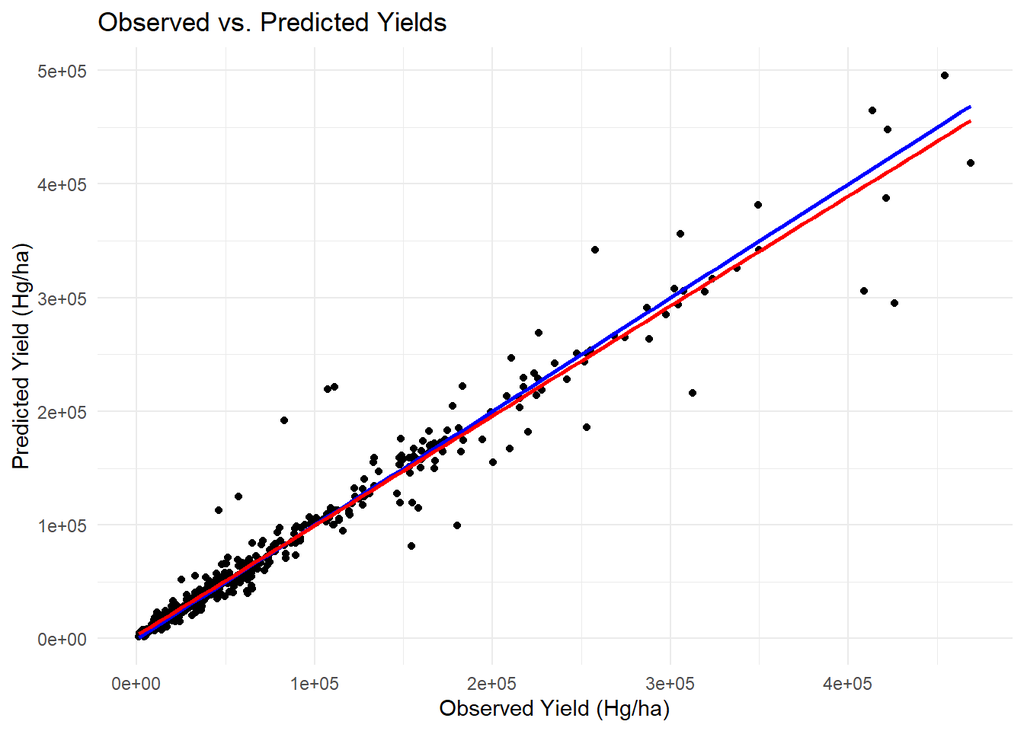

```r
ggplot(yield_test_with_results)+
  geom_point(aes(y = Prediction, x = yield_hg_per_ha))+
  stat_smooth(aes(y = yield_hg_per_ha, yield_hg_per_ha),
             method = "lm", se = FALSE, size = 1, colour="blue") +
  stat_smooth(aes(y = Prediction, x = yield_hg_per_ha),
              method = "lm", se = FALSE, size = 1, colour="red") +
  theme_minimal() +
  labs(title = "Observed vs. Predicted Yields",
       x = "Observed Yield (Hg/ha)",
       y = "Predicted Yield (Hg/ha)")
```

# 3. Binary Logistic Regression for Classification

**Binary logistic regression, or “logit”** is designed to **estimate binary outcomes**. If you have an outcome with two levels (say 0 and 1), it can estimate the odds that your combination of independent variables predicts the dependent variable to be a “1”. You can use these estimates as a way to classify things.

Let’s say I have a bunch of observations about fruit - their color, their weight, their shape - and I want to classify them as:

-`0` “It’s not an apple”

-`1` “It’s an apple.”

**The model produces predictions that range from 0-1 - representing probabilities or odds**. A combination of variables like “green”, and “round” might produce a probability of 0.6 that “It’s an apple.” We determine a *threshold* to *classify* your predictions as “1” or “0”. If our threshold was 0.5, we would say that yes, “this is an apple”.

The model works by fitting an s-shaped function to 0/1 data, like this:

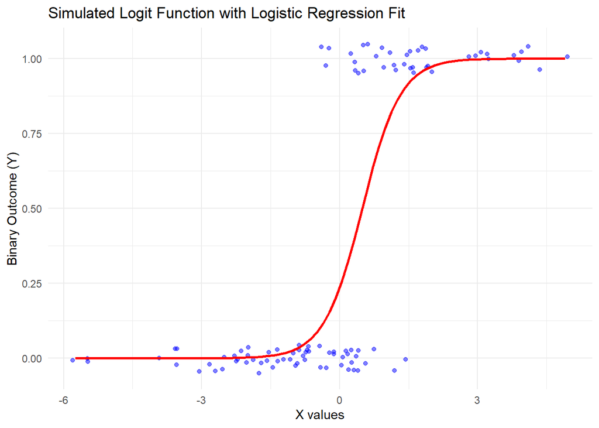

## 3.1. Data set

For our modeling workflow example, we will use a data set about tree survival published [by the aptly named Wood et al](https://datadryad.org/stash/dataset/doi:10.5061/dryad.xd2547dpw) at Michigan State. These data consist of ~2700 observations of trees, whether they are dead or alive, and a list of traits of that tree and the immediate environment.

We will try to *create a predictive classifier* that can estimate whether trees are dead or alive.

**The “use case” for our modeling example will be a forester who is interested in targeting dead trees for removal and sale as timber product.**

```r
trees <- read_csv ("https://raw.githubusercontent.com/mafichman/applied_predictive_modeling/refs/heads/main/data/tree_morbidity.csv") %>%
  filter(is.na(Event)== FALSE) %>%
  mutate(Species = as.factor(Species),
         Event = as.factor(Event))
```

## 3.2. Exploratory Analysis

Let’s take a look at our data set - **our dependent variable is called `Event`** - and it is binary.

It’s 1 if the tree is dead, and 0 if it’s not.

We will take a similar approach as we did with OLS regression, examining variables in relation to one another and to the dependent variable.

## 3.2.1. Looking at our data set

```r
glimpse(trees)
```

```
## Rows: 2,782
## Columns: 24
## $ No          <dbl> 126, 11, 12, 2823, 5679, 18, 25, 40, 26, 41, 30, 33, 34, 3…
## $ Plot        <dbl> 1, 1, 1, 7, 14, 1, 1, 1, 1, 1, 1, 1, 1, 1, 1, 1, 1, 1, 1, …
## $ Subplot     <chr> "C", "C", "C", "D", "A", "C", "A", "A", "A", "A", "C", "C"…
## $ Species     <fct> Acer saccharum, Quercus alba, Quercus rubra, Acer saccharu…
## $ Light_ISF   <dbl> 0.106, 0.106, 0.106, 0.080, 0.060, 0.106, 0.108, 0.108, 0.…
## $ Light_Cat   <chr> "Med", "Med", "Med", "Med", "Low", "Med", "Med", "Med", "M…
## $ Core        <dbl> 2017, 2017, 2017, 2016, 2017, 2016, 2016, 2017, 2016, 2016…
## $ Soil        <chr> "Prunus serotina", "Quercus rubra", "Prunus serotina", "Pr…
## $ Adult       <chr> "I", "970", "J", "J", "689", "1332", "891", "1595", "1323"…
## $ Sterile     <chr> "Non-Sterile", "Non-Sterile", "Non-Sterile", "Non-Sterile"…
## $ Conspecific <chr> "Heterospecific", "Heterospecific", "Heterospecific", "Het…
## $ Myco        <chr> "AMF", "EMF", "EMF", "AMF", "AMF", "AMF", "EMF", "EMF", "E…
## $ SoilMyco    <chr> "AMF", "EMF", "AMF", "AMF", "AMF", "AMF", "EMF", "Sterile"…
## $ PlantDate   <chr> "6/11/18", "5/25/18", "5/31/18", "6/11/18", "6/11/18", "6/…
## $ AMF         <dbl> 22.00, 15.82, 24.45, 22.23, 21.15, 35.29, 24.00, 4.00, 28.…
## $ EMF         <dbl> NA, 31.07, 28.19, NA, NA, NA, 20.00, 0.00, 36.18, NA, 28.1…
## $ Phenolics   <dbl> -0.56, 5.19, 3.36, -0.71, -0.58, 0.30, 5.11, 3.43, 3.83, -…
## $ Lignin      <dbl> 13.86, 20.52, 24.74, 14.29, 10.85, 10.80, 18.82, 25.22, 26…
## $ NSC         <dbl> 12.15, 19.29, 15.01, 12.36, 11.20, 13.79, 22.51, 14.81, 14…
## $ Census      <dbl> 4, 33, 18, 4, 4, 7, 7, 7, 33, 7, 33, 21, 21, 17, 7, 33, 7,…
## $ Time        <dbl> 14.0, 115.5, 63.0, 14.0, 14.0, 24.5, 24.5, 24.5, 115.5, 24…
## $ Event       <fct> 1, 0, 1, 1, 1, 1, 0, 0, 0, 1, 0, 1, 1, 1, 0, 0, 0, 0, 0, 1…
## $ Harvest     <chr> NA, NA, NA, NA, NA, NA, "X", "X", NA, NA, NA, NA, NA, NA, …
## $ Alive       <chr> NA, "X", NA, NA, NA, NA, NA, NA, "X", NA, "X", NA, NA, NA,…
```

## 3.2.2. Comparing continuous predictors across levels

We can use some simple `dplyr` logic to look at whether the our continuous variables differ depending on whether our `Event` binary outcome is 1 or 0.

*If there is a difference, this means there is a possibility that our model can use this feature to differentiate between our 1’s and 0’s.*

Let’s compare the means of our continuous variables - do dead trees and live trees have differing values?

At first glance, it looks like lower concentration of lignin and phenolics in the organism is associated with death, as is time (which is time from planting to harvesting).

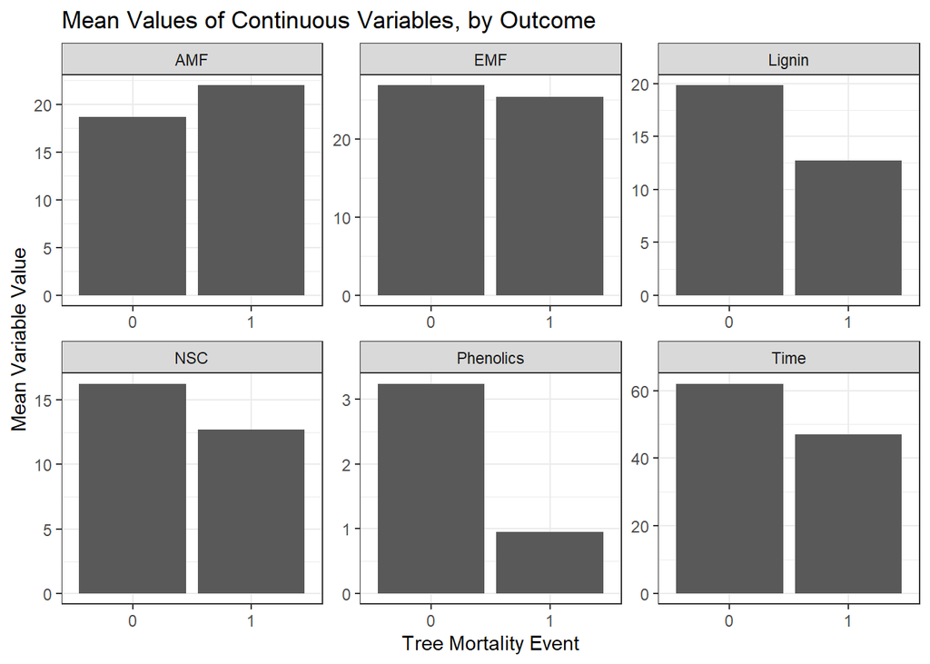

```r
trees %>%
  select(Event, Time, NSC, Lignin, Phenolics, EMF, AMF) %>%
  gather(-Event, key = "variable", value = "value") %>%
  group_by(variable, Event) %>%
  summarize(mean = mean(value, na.rm = TRUE)) %>%
ggplot()+
  geom_bar(aes(y = mean, x = Event), stat = "identity")+
  facet_wrap(~variable, scales = "free")+
    theme_bw()+
  labs(title = "Mean Values of Continuous Variables, by Outcome",
       x = "Tree Mortality Event",
       y = "Mean Variable Value")
```

Another approach worth trying is looking at the distributions of the continuous variables. Do the 1’s look different from the 0’s? We can examine this by making histograms.

We can see that amongst trees that die, lignin and phenolics and NSC seem to have right tailed distributions, and there’s a discrete split at a certain value. We can also see that something seems kind of weird with the “Time” variable - maybe it represents two harvest periods.

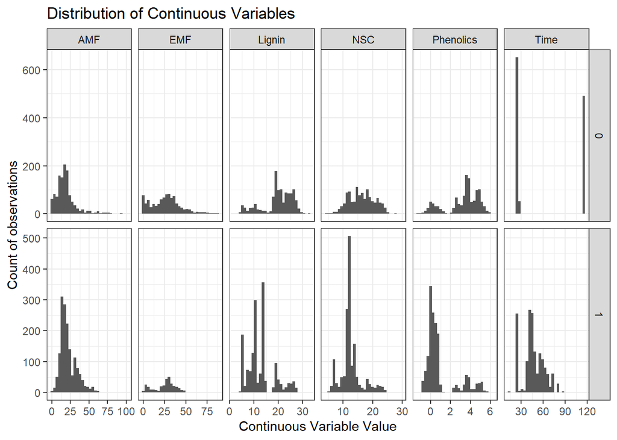

```r
trees %>%
    select(Event, Time, NSC, Lignin, Phenolics, EMF, AMF) %>%
    gather(-Event, key = "variable", value = "value") %>%
    ggplot()+
    geom_histogram(aes(value))+
    facet_grid(Event~variable, scales = "free")+
    theme_bw()+
  labs(title = "Distribution of Continuous Variables",
       x = "Continuous Variable Value",
       y = "Count of observations")
```

## 3.2.3. Comparing categorical predictors across levels

We can use some simple `dplyr` logic to look at whether our categorical variables vary depending on whether our `Event` binary outcome is 1 or 0.

It seems like species has a big effect - huge differences between the species in the frequency of 0’s and 1’s.

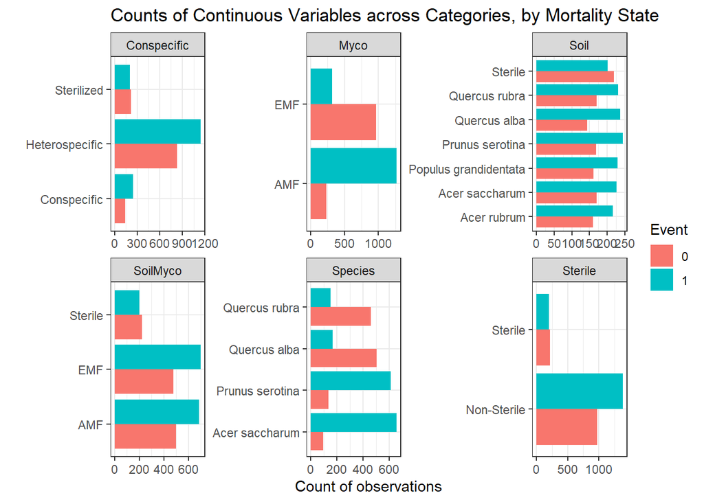

```r
trees %>%
  select(Event, Soil, Sterile, Conspecific, Myco, SoilMyco, Species) %>%
  gather(-Event, key = "variable", value = "value") %>%
  count(variable, value, Event) %>%
  ggplot()+
  geom_bar(aes(value, n, fill = Event),
           position = "dodge", stat="identity") +
  facet_wrap(~variable, scales="free") +
  coord_flip()+
    theme_bw() +
  labs(title = "Counts of Continuous Variables across Categories, by Mortality State",
       x = "",
       y = "Count of observations")
```

## 3.3. A Simple Model

Let’s make a simple model using the `glm` function, and setting the model `family = "binomial"` to specify a logit model. The form of the model code is otherwise the same as with `lm`.

Our model is a mix of fixed effects and continuous variables. We saw before that soil types (`Soil`) and mycorrhizal types (`Myco`) tend to be more or less redundant, so I’ve left one of those out of the model, figuring they “explain” the same information.

```r
reg_logit <- glm(data = trees ,
                 Event ~ Light_ISF + NSC + Lignin + Phenolics + Species + Soil,
                 family="binomial")
```

Let’s examine a model summary and quickly go over some of the statistics and outputs you see there.

```r
summary(reg_logit)
```

```
##
## Call:
## glm(formula = Event ~ Light_ISF + NSC + Lignin + Phenolics +
##     Species + Soil, family = "binomial", data = trees)
##
## Coefficients:
##                           Estimate Std. Error z value Pr(>|z|)
## (Intercept)                0.70756    0.46319   1.528 0.126618
## Light_ISF                 -8.30031    2.33046  -3.562 0.000369 ***
## NSC                        0.09949    0.02307   4.312 1.62e-05 ***
## Lignin                     0.05112    0.02391   2.139 0.032469 *
## Phenolics                 -0.30139    0.13281  -2.269 0.023245 *
## SpeciesPrunus serotina     0.07049    0.20873   0.338 0.735594
## SpeciesQuercus alba       -2.93569    0.67012  -4.381 1.18e-05 ***
## SpeciesQuercus rubra      -2.99732    0.58860  -5.092 3.54e-07 ***
## SoilAcer saccharum         0.19388    0.19037   1.018 0.308475
## SoilPopulus grandidentata  0.25709    0.18641   1.379 0.167853
## SoilPrunus serotina        0.25235    0.18916   1.334 0.182183
## SoilQuercus alba           0.42080    0.19288   2.182 0.029132 *
## SoilQuercus rubra          0.26095    0.19001   1.373 0.169655
## SoilSterile               -0.36818    0.18994  -1.938 0.052581 .
## ---
## Signif. codes:  0 '***' 0.001 '**' 0.01 '*' 0.05 '.' 0.1 ' ' 1
##
## (Dispersion parameter for binomial family taken to be 1)
##
##     Null deviance: 3801.3  on 2781  degrees of freedom
## Residual deviance: 2664.6  on 2768  degrees of freedom
## AIC: 2692.6
##
## Number of Fisher Scoring iterations: 4
```

The **coefficients show the strength and direction of the relationship**. They are interpretable in terms of the “log odds” of the dependent variable being a “1”. This is not very useful when you are trying to understand relationships, so you can exponentiate the coeffecients to “un-log” them and just get plain “odds”. (see the outputs below)

So for example, if the exponentiated coefficient was 1.14, you’d say “All else equal, on average, the odds of a tree dying increase by 14% with a unit change in the independent variable.”

If you have a fixed effect, you are comparing the odds between the levels of that fixed effect, “All else equal, on average, the odds of a tree of species A_____ dying are X times that of tree of species B”

You can try that here:

```r
exp_coef <- reg_logit$coefficients %>%
  as.data.frame() %>%
  rename(coefficient = ".") %>%
  mutate(exponentiated = exp(coefficient))
```

```r
exp_coef %>%
  kable() %>%
  kable_styling()
```

|  | coefficient | exponentiated |
| --- | --- | --- |
| (Intercept) | 0.7075570 | 2.0290283 |
| Light_ISF | -8.3003139 | 0.0002484 |
| NSC | 0.0994876 | 1.1046048 |
| Lignin | 0.0511236 | 1.0524530 |
| Phenolics | -0.3013901 | 0.7397891 |
| SpeciesPrunus serotina | 0.0704866 | 1.0730302 |
| SpeciesQuercus alba | -2.9356888 | 0.0530941 |
| SpeciesQuercus rubra | -2.9973229 | 0.0499205 |
| SoilAcer saccharum | 0.1938779 | 1.2139480 |
| SoilPopulus grandidentata | 0.2570858 | 1.2931561 |
| SoilPrunus serotina | 0.2523539 | 1.2870514 |
| SoilQuercus alba | 0.4208002 | 1.5231798 |
| SoilQuercus rubra | 0.2609463 | 1.2981580 |
| SoilSterile | -0.3681777 | 0.6919942 |

The **p-values** are similar to those from OLS - they represent the probability that the coefficient’s value is significantly different from zero - basically, our confidence the in the coefficient estimate.

## 3.4. Training and Testing

## 3.4.1. Splitting our Data

This process is identical to what we did in training an OLS model.

We use the `set.seed` command to generate a random number sequence. We then use the `createDataPartition` command from the `caret` package to split our data. The p argument takes a number - here we say .70 to indicate that we want 70% of our data in the training set. There’s no set rule for the split size. The `paste` command is where we specify categorical variables - we want to make sure that single observations of categories end up in our test set.

We create two data frames - `treeTrain` and `treeTest`.

```r
set.seed(1234)

treetrainIndex <- createDataPartition(y = paste(trees$Species, trees$Soil),
                                  p = .70,
                                  list = FALSE,
                                  times = 1)

treeTrain <- trees[ treetrainIndex,]
treeTest  <- trees[-treetrainIndex,]
```

## 3.4.2. Creating a Regression

Let’s put our independent variables from `reg_logit` into a `glm` logit model we trained on our training set, `treeTrain`. We will call this model `logit_train`

```r
logit_train <- glm(data = treeTrain, Event ~ Light_ISF + NSC + Lignin + Phenolics +
                                       Species + Soil,
                 family="binomial"(link="logit"))
```

## 3.4.3. Predicting for our Test Set

We `mutate` a new column in our `treeTest` test set that contains our estimates. We use the `predict` function to do this.

`predict` takes a few arguments - our model `logit_train`, and a data set, `treeTest`. We set the `type` to equal `"response"` to output exponentiated values (e.g. the probabilities, not the “log odds”).

Our model only knows how to make predictions for a data frame that contains the exact same information it has “seen” when we trained it with`treeTrain` - so your test set has to have exactly the same columns - same names, same data types - for this to work.

```r
treeTest_with_results <-
  treeTest %>%
  mutate(estimate = predict(logit_train, treeTest,  type="response"))
```

The predictions are not 1’s and 0’s, they fall in the range 0-1 - they are odds of the outcome being 0 or 1.

We need to classify them according to some threshold - above that threshold, we will classify it a 1, below we will classify it a 0.

Let’s examine a histogram of our estimates to see what our range of values is. We can see it’s pretty bi-modal.

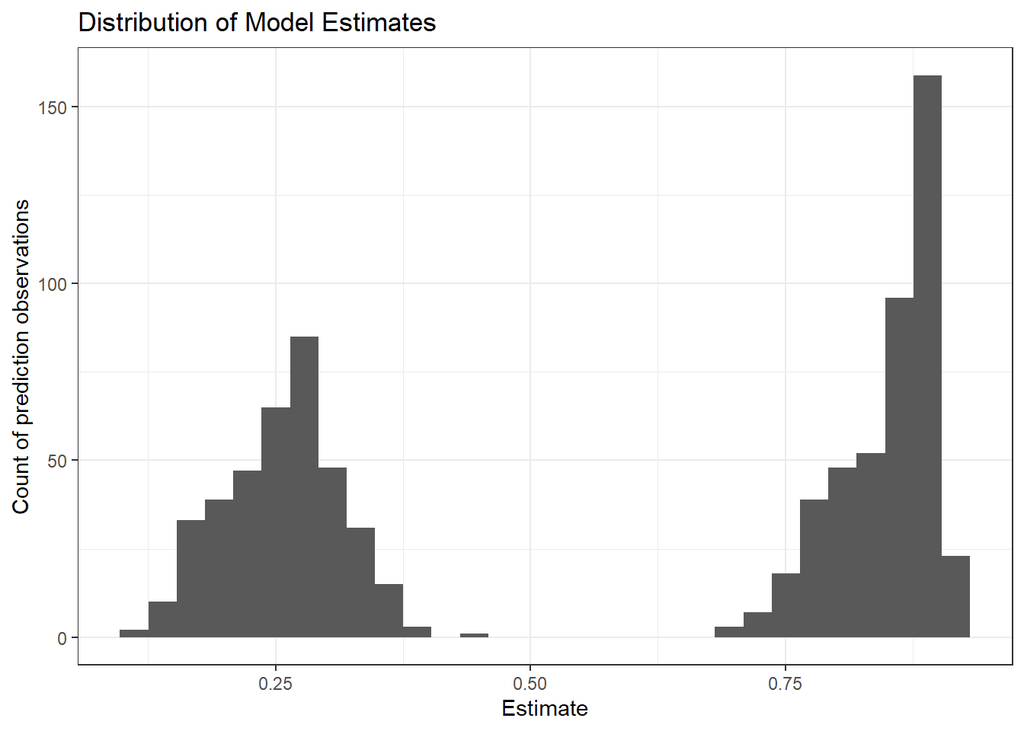

```r
ggplot()+
  geom_histogram(data = treeTest_with_results, aes(estimate))+
  theme_bw() +
  labs(title = "Distribution of Model Estimates",
       x = "Estimate",
       y = "Count of prediction observations")
```

## 3.4.4. Understanding Accuracy - Setting a Threshold for Classification

Remember, in our test data, we know the *actual* outcomes for each observation (`Event`). If we split our estimates along those lines, we can see that we have some high and low probabilities in both categories, but on average we seem to be getting mostly high probabilities for our 1’s and low probabilities for our 0’s. That’s good!

In our next step, we will move forward with a threshold of 0.4 - if our estimate is above that, we will say we are classifying this an estimated `1`, otherwise, a `0`. This means we will have a lot of accurate classifications, but also some errors.

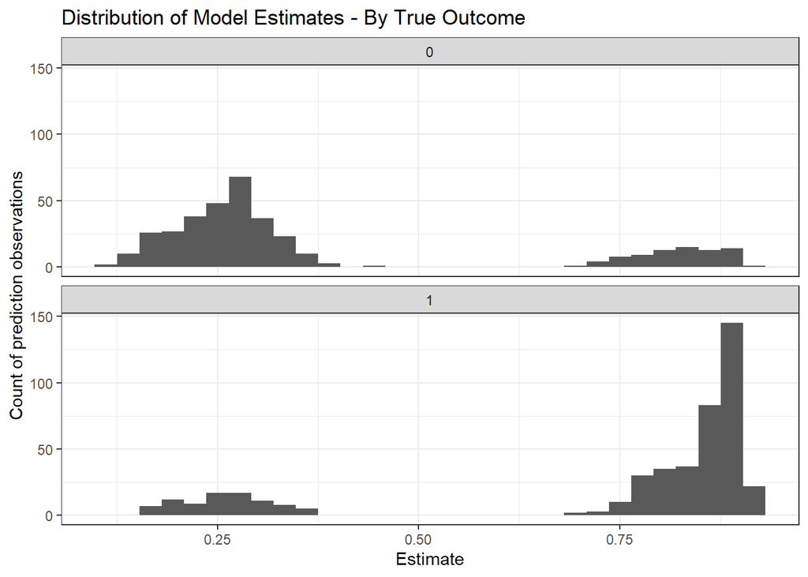

```r
treeTest_with_results %>%
  ggplot()+
  geom_histogram(aes(estimate))+
  facet_wrap(~Event, nrow= 2)+
  theme_bw()+
  labs(title = "Distribution of Model Estimates - By True Outcome",
       x = "Estimate",
       y = "Count of prediction observations")
```

### 3.4.5. Confusion Metrics - Understanding Our 4 Outcomes

Let’s create the `treeTest_with_results` dataframe again using the `predict` function, but let’s add a new column called `prediction` that says “if the prediction is greater or equal to 0.4, prediction = 1, otherwise, it’s a 0.”

```r
treeTest_with_results <-
  treeTest %>%
  mutate(estimate = predict(logit_train, .,  type="response"),
         prediction = as.factor(ifelse(estimate >= 0.4, 1, 0)))
```

We are going to have four outcomes to our model, and it’s important to be able to understand these by explaining them in plain English.

**True Positive** - We predicted the tree would die, and it did die.

**True Negative** - We predicted the tree would not die, and it did not die.

**False Positive** - We predicted the tree would die, and it did not. (An error!)

**False Negative** - We predicted the tree would not die, and it did. (Also an error!)

Our overall accuracy is the amount of True Positives and True Negatives as a percentage of total observations.

Logistic regression has a ton of (confusing) terms, among those are “sensitivity” and “specificity”

**Sensitivity** - True Positive Rate - the percentage of positives we classify correctly

**Specificity** - True Negative Rate - the percentage of negatives we classify correctly

Fittingly, there is a thing called a “Confusion Matrix” which shows us a range of statistics associated with our classification model:

```r
caret::confusionMatrix(treeTest_with_results$prediction, as.factor(treeTest_with_results$Event), positive = "1")
```

```
## Confusion Matrix and Statistics
##
##           Reference
## Prediction   0   1
##          0 292  86
##          1  79 367
##
##                Accuracy : 0.7998
##                  95% CI : (0.7708, 0.8266)
##     No Information Rate : 0.5498
##     P-Value [Acc > NIR] : <2e-16
##
##                   Kappa : 0.5962
##
##  Mcnemar's Test P-Value : 0.6404
##
##             Sensitivity : 0.8102
##             Specificity : 0.7871
##          Pos Pred Value : 0.8229
##          Neg Pred Value : 0.7725
##              Prevalence : 0.5498
##          Detection Rate : 0.4454
##    Detection Prevalence : 0.5413
##       Balanced Accuracy : 0.7986
##
##        'Positive' Class : 1
##
```

You can make your own version of this using `mutate` commands, and then assess model accuracy across categories.

If we look at our model performance across species, we see that our model tends to predict negatives (eg 0) for our Quercus species - be those true or false negatives.

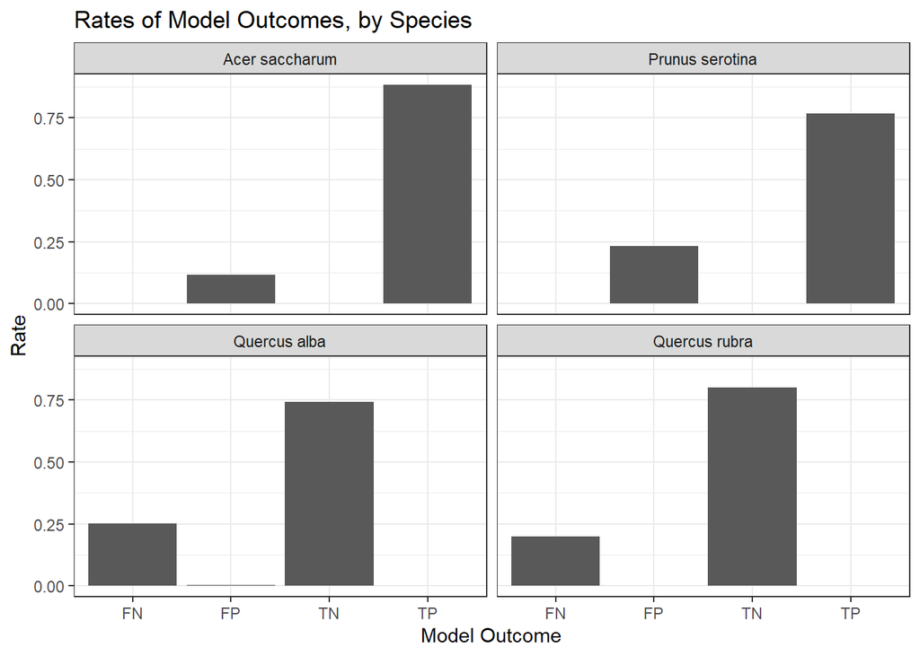

```r
treeTest_with_results %>%
  mutate(outcome = case_when(prediction == 1 & Event == 1 ~ "TP",
                             prediction == 1 & Event == 0 ~ "FP",
                             prediction == 0 & Event == 0 ~ "TN",
                             prediction == 0 & Event == 1 ~ "FN")) %>%
  group_by(Species, outcome) %>%
  summarize(
    count = n(),                              # Count the number of rows for each outcome
    .groups = "drop"
  ) %>%
  group_by(Species) %>%
  mutate(
    total = sum(count),                       # Total outcomes per species
    rate = count / total                      # Rate of each outcome within species
  ) %>%
  ggplot()+
  geom_bar(aes(x = outcome, y = rate), stat = "identity")+
  facet_wrap(~Species)+
  theme_bw() +
  labs(title = "Rates of Model Outcomes, by Species",
       x = "Model Outcome",
       y = "Rate")
```

### 3.4.6. ROC Curves

The ROC curve (or “receiver operating characteristic” curve) is a diagnostic to see how well our model is performing.

In the plot below - the y=x line represents a model that’s a “coin flip” - by just guessing 1’s and 0’s you could make a model like this. If our ROC curve is convex and north of the line (like the one you see below) - it means that we have a fairly good model - we are doing better than a coin flip. If our model were a hard right angle shape - it would mean our model is “overfit” - it’s predicting with extremely high accuracy, and probably is inflexible to new information.

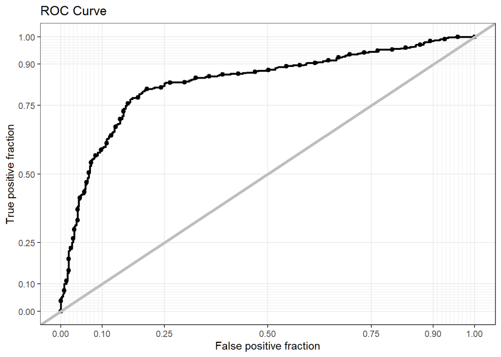

```r
ggplot(treeTest_with_results, aes(d = as.numeric(Event), m = as.numeric(estimate))) +
  geom_roc(n.cuts = 50, labels = FALSE) +
  style_roc(theme = theme_grey) +
  geom_abline(slope = 1, intercept = 0, size = 1.5, color = 'grey')+
  theme_bw()+
  labs(title = "ROC Curve")
```

# 4. Feature engineering methods

The key to making a really good model is engineering independent variables that are strongly predictive of the dependent variable. In the examples above, the data sets we used were very clean, and had good predictive accuracy as-is. In real life, that’s not usually the case. To make a good model, you need to use your intuition about the phenomenon you are modeling to form a hypothesis about what kind of information might be predictive of your outcome.

This might mean joining your data to a new data set (using a tabular or spatial join), recategorizing variables you already have in your set, or transforming them to conform to the assumptions of the model type in order get more predictive power.

This section presents a sampling of feature engineering methods, including some spatial feature creation techniques.

## 4.1. Data

Let’s use some data on 2023 Philadelphia home sales from the City of Philadelphia Office of Property Assessment to attempt to predict sales prices for single family homes. Our dependent variable will be `sale_price`, a continuous outcome.

The general model approach will be the “hedonic” model, where the price of a good is decomposed into it’s constituent parts.

For homes, this means the price is a function of the internal characteristics (number of bedrooms, bathrooms, AC, garage, fixtures) the location (and the local amenities like schools), the condition, lot size, and comparable sales (nearby prices).

Let’s load in some data - these are spatial data (geojson), which we can read using `st_read` from the `sf` package. Each house has a point geometry associated with it.

```r
homes <- st_read("https://raw.githubusercontent.com/mafichman/applied_predictive_modeling/refs/heads/main/data/homes.geojson") %>%
  st_as_sf() %>%
  st_transform(4326)
```

These are spatial data, we can use the `sf` package and `ggplot` to map them.

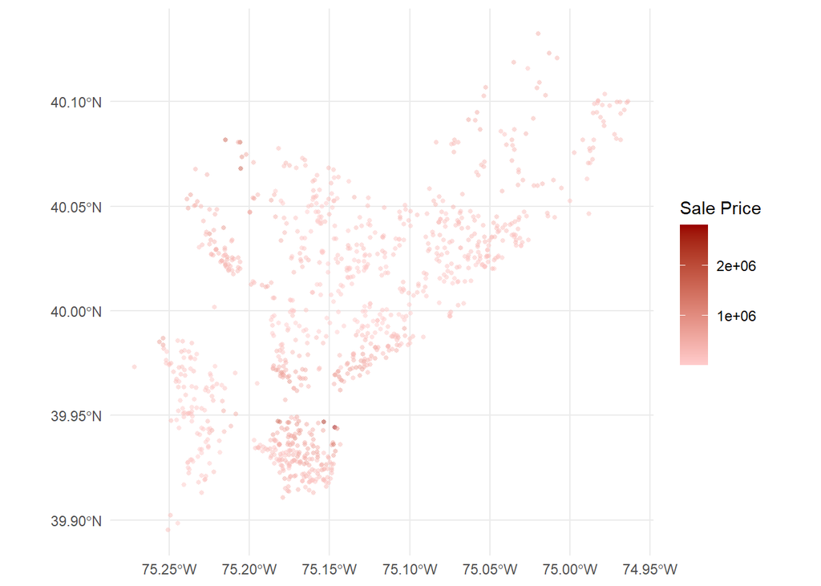

```r
ggplot()+
  geom_sf(data = homes %>%
            sample_n(1000), aes(color = sale_price),
          alpha = 0.5, shape = 16, size = 1, show.legend = TRUE)+
  scale_color_gradient(low = "#FFCCCC", high = "#990000", name = "Sale Price") +  # Light red to dark red
  theme_minimal()
```

We can make a very basic hedonic model using bedrooms, bathrooms, year built, and total livable area to see how much variance our basic predictors explain in the dependent variable `sale_price`.

The R-Squared is about .51.

```r
summary(lm(data = homes, sale_price ~ year_built + number_of_bedrooms + number_of_bathrooms + total_livable_area))
```

```
##
## Call:
## lm(formula = sale_price ~ year_built + number_of_bedrooms + number_of_bathrooms +
##     total_livable_area, data = homes)
##
## Residuals:
##      Min       1Q   Median       3Q      Max
## -2153733   -86050   -12881    61739  3706061
##
## Coefficients:
##                       Estimate Std. Error t value Pr(>|t|)
## (Intercept)         222963.229  85129.696   2.619  0.00882 **
## year_built            -120.301     43.875  -2.742  0.00611 **
## number_of_bedrooms  -81701.936   2224.584 -36.727  < 2e-16 ***
## number_of_bathrooms 136591.831   2586.226  52.815  < 2e-16 ***
## total_livable_area     264.763      3.248  81.512  < 2e-16 ***
## ---
## Signif. codes:  0 '***' 0.001 '**' 0.01 '*' 0.05 '.' 0.1 ' ' 1
##
## Residual standard error: 161500 on 19722 degrees of freedom
## Multiple R-squared:  0.5119, Adjusted R-squared:  0.5118
## F-statistic:  5171 on 4 and 19722 DF,  p-value: < 2.2e-16
```

## 4.2. Reclassification

I have a hypothesis that the relationship between a house’s age and it’s sale price is not continuous. A new house might be very desirable, a post-war house might be in need of major renovations, and a house built in the 1700s or 1800s might have historic appeal. Take a look at the scatterplot below - there are some time “bands” of very high value homes, and some that are less valuable.

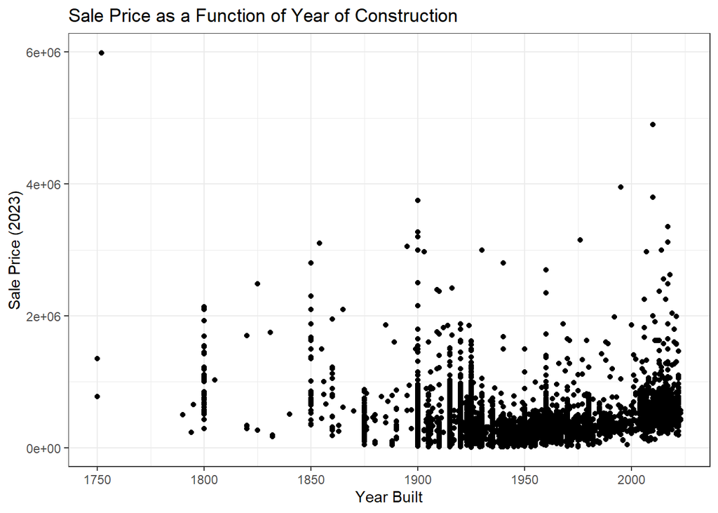

```r
ggplot(homes)+
  geom_point(aes(x = year_built, y = sale_price))+
  theme_bw()+
  labs(title = "Sale Price as a Function of Year of Construction",
       x = "Year Built",
       y = "Sale Price (2023)")
```

The `case_when` function from `dplyr` is great for this.

```r
homes <- homes %>%
  mutate(age_categorical = case_when(year_built <= 1880 ~ "historic",
                                     year_built > 1880 &
                                       year_built <= 1920 ~ "victorian",
                                     year_built > 1920 &
                                       year_built <= 1980 ~ "mid-century",
                                     year_built < 1980 &
                                       year_built <= 2000 ~ "modern",
                                     year_built > 2000 ~ "modern"))
```

Let’s also specify that number of bedrooms are different categories - not numerical variables. A 6 bedroom house isn’t inherently 3x more valuable than a 2 bedroom house - they are totally different types of homes!

```r
homes <- homes %>%
  mutate(bedrooms_categorical = as.factor(number_of_bedrooms))
```

How does this affect our model? It improves it a little bit!

```r
summary(lm(data = homes, sale_price ~ bedrooms_categorical + number_of_bathrooms + total_livable_area + age_categorical))
```

```
##
## Call:
## lm(formula = sale_price ~ bedrooms_categorical + number_of_bathrooms +
##     total_livable_area + age_categorical, data = homes)
##
## Residuals:
##      Min       1Q   Median       3Q      Max
## -1771938   -83049   -10836    62610  3683794
##
## Coefficients:
##                              Estimate Std. Error t value Pr(>|t|)
## (Intercept)                 1.291e+05  1.423e+04   9.071  < 2e-16 ***
## bedrooms_categorical2      -8.754e+04  1.220e+04  -7.173 7.62e-13 ***
## bedrooms_categorical3      -1.765e+05  1.190e+04 -14.836  < 2e-16 ***
## bedrooms_categorical4      -2.202e+05  1.260e+04 -17.474  < 2e-16 ***
## bedrooms_categorical5      -2.814e+05  1.580e+04 -17.805  < 2e-16 ***
## bedrooms_categorical6      -3.879e+05  1.997e+04 -19.429  < 2e-16 ***
## bedrooms_categorical7      -6.774e+05  3.561e+04 -19.023  < 2e-16 ***
## bedrooms_categorical8      -5.442e+05  5.272e+04 -10.323  < 2e-16 ***
## bedrooms_categorical9      -5.375e+05  1.130e+05  -4.759 1.96e-06 ***
## number_of_bathrooms         1.208e+05  2.724e+03  44.355  < 2e-16 ***
## total_livable_area          2.532e+02  3.304e+00  76.639  < 2e-16 ***
## age_categoricalmid-century -1.928e+05  7.785e+03 -24.764  < 2e-16 ***
## age_categoricalmodern      -1.217e+05  9.361e+03 -13.004  < 2e-16 ***
## age_categoricalvictorian   -1.730e+05  7.898e+03 -21.908  < 2e-16 ***
## ---
## Signif. codes:  0 '***' 0.001 '**' 0.01 '*' 0.05 '.' 0.1 ' ' 1
##
## Residual standard error: 156400 on 19482 degrees of freedom
##   (231 observations deleted due to missingness)
## Multiple R-squared:  0.5327, Adjusted R-squared:  0.5324
## F-statistic:  1708 on 13 and 19482 DF,  p-value: < 2.2e-16
```

## 4.3. Spatial Variables

What’s the most important thing about a house? Location, Location, Location - that’s what they always say!

Let’s create variables that account for some things about a house’s location.

### 4.3.1. Spatial Fixed Effects

We can join our homes to the zip codes to which they belong. This creates a proxy variable for “neighborhood” that you can use as a fixed effect in a model.

Let’s load a shape of Philadelphia zip codes and make sure it’s projected in crs = 4326 (same as our homes) by using `st_transform`.

```r
zips <- st_read("https://raw.githubusercontent.com/mafichman/applied_predictive_modeling/refs/heads/main/data/zctas_philly.geojson") %>%
  st_as_sf() %>%
  st_transform(4326)
```

Now we can do a point-in-polygon join, adding our zip code information to our homes.

```r
homes <- st_join(homes, zips)
```

We can code zip code as a categorical variable - each “neighborhood” represents a different category of location.

```r
homes <- homes %>%
  mutate(zip_code = as.factor(zip_code))
```

When we calculate and plot the mean sales price by zip code, we can see that this is a potentially powerful predictor - there is very wide variation across zip codes.

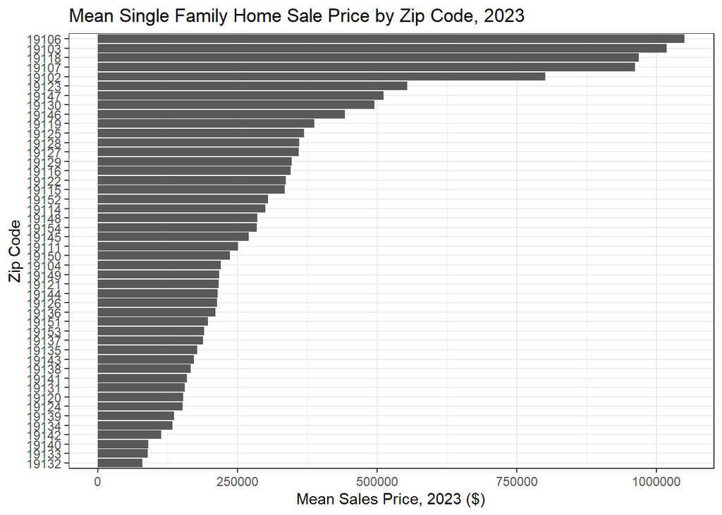

```r
homes %>%
  group_by(zip_code) %>%
  summarize(mean_price = mean(sale_price)) %>%
  ggplot()+
  geom_bar(aes(x = fct_reorder(zip_code, mean_price), y = mean_price), stat = "identity")+
  coord_flip()+
  theme_bw()+
  labs(title= "Mean Single Family Home Sale Price by Zip Code, 2023",
       x = "Zip Code",
       y = "Mean Sales Price, 2023 ($)")
```

If we run another model that includes the `zip_code` fixed effect. We can see that there is an enormous boost in the R-squared value.

```r
summary(lm(data = homes, sale_price ~ bedrooms_categorical + number_of_bathrooms + total_livable_area + age_categorical + zip_code))
```

```
##
## Call:
## lm(formula = sale_price ~ bedrooms_categorical + number_of_bathrooms +
##     total_livable_area + age_categorical + zip_code, data = homes)
##
## Residuals:
##      Min       1Q   Median       3Q      Max
## -1259967   -55709     -666    51696  3297446
##
## Coefficients:
##                              Estimate Std. Error t value Pr(>|t|)
## (Intercept)                 2.186e+05  1.250e+05   1.748 0.080424 .
## bedrooms_categorical2       1.503e+05  1.024e+04  14.669  < 2e-16 ***
## bedrooms_categorical3       1.371e+05  1.022e+04  13.416  < 2e-16 ***
## bedrooms_categorical4       1.148e+05  1.079e+04  10.639  < 2e-16 ***
## bedrooms_categorical5       9.006e+04  1.337e+04   6.736 1.68e-11 ***
## bedrooms_categorical6       3.655e+04  1.667e+04   2.193 0.028317 *
## bedrooms_categorical7      -1.423e+05  2.911e+04  -4.889 1.02e-06 ***
## bedrooms_categorical8       1.466e+03  4.267e+04   0.034 0.972586
## bedrooms_categorical9       1.199e+05  9.056e+04   1.324 0.185593
## number_of_bathrooms         7.426e+04  2.255e+03  32.939  < 2e-16 ***
## total_livable_area          2.093e+02  2.746e+00  76.245  < 2e-16 ***
## age_categoricalmid-century -3.189e+04  7.703e+03  -4.140 3.48e-05 ***
## age_categoricalmodern       9.456e+03  8.526e+03   1.109 0.267410
## age_categoricalvictorian   -3.415e+04  7.657e+03  -4.460 8.24e-06 ***
## zip_code19103               2.385e+05  1.251e+05   1.906 0.056636 .
## zip_code19104              -4.826e+05  1.252e+05  -3.854 0.000116 ***
## zip_code19106               1.907e+05  1.260e+05   1.514 0.130038
## zip_code19107              -3.225e+04  1.277e+05  -0.252 0.800658
## zip_code19111              -4.474e+05  1.250e+05  -3.581 0.000344 ***
## zip_code19114              -3.984e+05  1.251e+05  -3.183 0.001458 **
## zip_code19115              -4.268e+05  1.251e+05  -3.410 0.000651 ***
## zip_code19116              -4.034e+05  1.252e+05  -3.221 0.001279 **
## zip_code19118              -8.171e+04  1.255e+05  -0.651 0.514922
## zip_code19119              -4.207e+05  1.250e+05  -3.365 0.000766 ***
## zip_code19120              -4.994e+05  1.249e+05  -3.998 6.41e-05 ***
## zip_code19121              -4.642e+05  1.250e+05  -3.714 0.000204 ***
## zip_code19122              -4.093e+05  1.251e+05  -3.273 0.001067 **
## zip_code19123              -3.004e+05  1.253e+05  -2.398 0.016493 *
## zip_code19124              -4.998e+05  1.249e+05  -4.002 6.30e-05 ***
```

[output cut: 22 more lines]

```
## zip_code19147              -2.262e+05  1.249e+05  -1.811 0.070134 .
## zip_code19148              -3.684e+05  1.249e+05  -2.950 0.003179 **
## zip_code19149              -4.403e+05  1.249e+05  -3.525 0.000425 ***
## zip_code19150              -4.659e+05  1.251e+05  -3.725 0.000196 ***
## zip_code19151              -4.918e+05  1.250e+05  -3.933 8.41e-05 ***
## zip_code19152              -3.989e+05  1.252e+05  -3.187 0.001438 **
## zip_code19153              -4.641e+05  1.254e+05  -3.701 0.000215 ***
## zip_code19154              -3.987e+05  1.250e+05  -3.190 0.001423 **
## ---
## Signif. codes:  0 '***' 0.001 '**' 0.01 '*' 0.05 '.' 0.1 ' ' 1
##
## Residual standard error: 124600 on 19437 degrees of freedom
##   (231 observations deleted due to missingness)
## Multiple R-squared:  0.7043, Adjusted R-squared:  0.7034
## F-statistic: 798.2 on 58 and 19437 DF,  p-value: < 2.2e-16
```

### 4.3.2. Spatial Lag Variables

You might want engineer variables that account for the distance of a house from the nearest commercial corridor, or the average price per square foot of the 3 nearest sales. Using the sf package, this is all possible.

These are what’s known as **k-nearest-neighbor** variables.

Using the `FNN` package, you could calculate the **nearest neighbor distance** from each home to the nearest 3 restaurants or parks.

Using the `spdep` package, you could calculate the **“spatial lag” of price”** - the average square footage price of the k nearest sales - a good parameter to represent “comps” - nearby sales (this method is demonstrated below using 5 nearest neighbors).

```r
library(spdep)


neighborList <- knn2nb(knearneigh(st_coordinates(homes), 5))

spatialWeights <- nb2listw(neighborList, style="W")

homes$lagPriceSqFt <- lag.listw(spatialWeights, homes$sale_price/homes$total_livable_area)
```

The spatially lagged sale price is very strongly correlated with sale price (see the `cor` statistic below), so this suggests it will be a good predictor in our linear model.

If we were to run a model (which I do not do here for the sake of sparing you another model summary to look at) - we would find our R-squared value increasing by about .05.

```r
cor.test(homes$sale_price, homes$lagPriceSqFt)
```

```
##
##  Pearson's product-moment correlation
##
## data:  homes$sale_price and homes$lagPriceSqFt
## t = 118.1, df = 19725, p-value < 2.2e-16
## alternative hypothesis: true correlation is not equal to 0
## 95 percent confidence interval:
##  0.6353290 0.6516799
## sample estimates:
##       cor
## 0.6435779
```

## 4.4 Variable Transformations, Interactions and Other Techniques

One of the core assumptions of regression modeling is that independent variables have a linear relationship with the dependent variable. With predictive modeling, we sometimes play fast and loose with assumptions, but the models do perform better when this is the case.

Here are some ways you can transform your variables and your data.

**Transformation** - You can take variables that don’t have a linear relationship with their predictors and transform them using log transformation. This is done very often with pricing models, where home prices are logged before modeling.

**Normalization** - you can use rate statistics or ratios as your modeling yardsticks. In the above example, we used the k-nearest neighbor price-per-square-foot, so that the size of nearby homes is not biasing our “comps” variable.

**Standardization** - you can recenter your variables in a normal distribution centered on zero.

**Outlier Removal** - Are we concerned that a few unusual cases are making it harder for our model to perform well? Throwing away outliers can help our model training process.

A last engineering technique is to “interact” variables.

**Interactions** - When the relationship between an independent predictor and the dependent variable depend on another predictor variable, you can *interact* the two variables in the model using the `*` multiply sign.

# 5. Model Cross-Validation

We made one training and testing split - but that might mean that our accuracy is an artifact of the training data we had, or the test data we used to validate it the first time. When we are selecting our “best” model, we might want to take a closer look at our model performance to make sure we didn’t just get lucky on our accuracy in the train/test error estimates.

A way to do this is to make many, many, random training and testing set splits - a group of processes called “cross-validation”.

This can be done with something called k-fold cross-validation, where we can make as many random splits as we want and train and test models.

Let’s try this out with our Philadelphia housing data. Let’s set k to be 100 and run our train/test split 100 times.

This is done with the `trainControl` function from `caret` using the method `cv` for Cross-Validation.

A note on the code procedure here - we pipe in our `homes` data set, and `select` the variables for our regression model, specifying the `lm` model. This set of variables includes our `lagPriceSqFt` spatial lag, our `zip_code` and the internal features and house age.

```r
fitControl <- trainControl(method = "cv", number = 100)
set.seed(825)

reg.cv <-
  train(sale_price ~ ., data = homes %>%
                                        as.data.frame() %>%
                                        select(bedrooms_categorical, number_of_bathrooms ,
                                               total_livable_area, age_categorical, zip_code,
                                               lagPriceSqFt, sale_price),
     method = "lm", trControl = fitControl, na.action = na.pass)
```

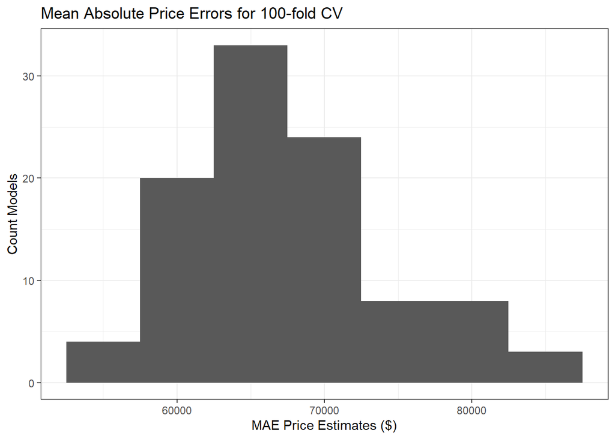

```r
ggplot(as.data.frame(reg.cv$resample)) +
  geom_histogram(aes(MAE), binwidth = 5000) +
  labs(title = "Mean Absolute Price Errors for 100-fold CV",
    x="MAE Price Estimates ($)",
       y="Count Models")+
  theme_bw()
```

There are some other methods for cross-validation worth mentioning.

With **“Leave One Group Out”** cross-validation - you can build a housing price model using all but one Philadelphia zip code, and see if it is accurate in the “hold out” zip code.

You can do this spatially as well - **“Leave One Geometry Out”** - holding out individual areas (probably zip codes in the housing use case) from training and subjecting them as test sets to see how well your model performs on “unseen” data.

# 6. Data Dictionaries

## 6.1. Crop Yield Dataset

```
- Area - The country
- Item - The crop
- Year - The year of the observation
- yield_hg_per_ha - Average crop yield in hectograms per hectre
- average_rain_fall_mm_per_year - Average rainfall in that year in that country
- pesticides_tonnes - Average pesticide application to that crop in that country, in that year
- avg_temp - Average temperatures in that country in that year (c)
- yield_last_year - A variable I calculated representing the previous year's yield in that country for that crop
```

## 6.2. Wood Et Al

```
- No: Seedling unique ID number.
- Plot: Number of the field plot the seedling was planted in. (1-18)
- Subplot: Subplot within the main plot the seedling was planted in. Broken into 5 subplots (1 per corner, plus 1 in the middle). (A-E)
- Species: Includes Acer saccharum, Prunus serotina, Quercus alba, and Quercus rubra.
- Light ISF: Light level quantified with HemiView software. Represents the amount of light reaching each subplot at a height of 1m.
- Light Cat: Categorical light level created by splitting the range of Light_ISF values into three bins (low, med, high).
- Core: Year the soil core was removed from the field.
- Soil: Species from which the soil core was taken. Includes all species, plus Acer rubrum, Populus grandidentata, and a sterilized conspecific for each species.
- Adult: Individual tree that soil was taken from. Up to 6 adults per species. Used as a random effect in analyses.
- Sterile: Whether the soil was sterilized or not.
- Conspecific: Whether the soil was conspecific, heterospecific, or sterilized conspecific.
- Myco: Mycorrhizal type of the seedling species (AMF or EMF).
- SoilMyco: Mycorrhizal type of the species culturing the soil (AMF or EMF).
- PlantDate: The date that seedlings were planted in the field pots.
- AMF: Percent arbuscular mycorrhizal fungi colonization on the fine roots of harvested seedlings.
- EMF: Percent ectomycorrhizal fungi colonization on the root tips of harvested seedlings.
- Phenolics: Calculated as nmol Gallic acid equivalents per mg dry extract (see manuscript for detailed methods)
- NSC: Calculated as percent dry mass nonstructural carbohydrates (see manuscript for detailed methods)
- Lignin: Calculated as percent dry mass lignin (see manuscript for detailed methods)
- Census: The census number at which time the seedling died or was harvested.
- Time: The number of days at which time the seedling died or was harvested.
- Event: Used for survival analysis to indicate status of each individual seedling at a given time (above)
    0 = harvested or experiment ended
    1 = dead
- Harvest: Indicates whether the seedling was harvested for trait measurement.
- Alive: Indicates if the seedling was alive at the end of the second growing season. "X" in this field indicates alive status.
```

## 6.3. Philadelphia Housing Data

This is a very expansive data set - you can examine the metadata [at the City of Philadelphia’s open data site](https://opendataphilly.org/datasets/philadelphia-properties-and-assessment-history/).